# Geoestadística para una variable

María Paula Camargo Rincón Laura Katherine Martinez Castiblanco

## 1 Capitulo 4

### 1.1 Suponga que $Z(s)$ es una función aleatoria estacionaria de segundo orden que representa la precipitación en los cuatro bordes de un trapecio recto. Las realizaciones registradas del fenómeno en estas cuatro ubicaciones son $z_1(0, 0) = 15$; $z_2(100, 0) = 16$; $z_3(0, 50) = 16$ y $z_4(70, 50) = 15$. El modelo de autocorrelación del fenómeno es exponencial con silla 4 y rango 100 m. Encuentre:

1. La predicción con su respectiva varianza de error de predicción, esto es, la varianza del kriging simple para la ubicación $Z(75, 25)$ si la media es conocida e igual a 15,7. Use para sus cálculos la función de covarianza.

   **R/** como tenemos que la **silla** es 4, entonces $C(0)=4=\sigma^2$, y el **rango** es 100, por ende $C(h)$ es

   $$C(h)=\sigma^2exp\left(-\frac{||h||}{a}\right)=4exp\left(-\frac{h}{100}\right)$$

   Obtenemos las distancias euclideanas y reemplazamos en la función de covarianza $C(h)$ con los puntos conocidos, los resultados seran guardados en una matriz $\mathbb{C}$, luego calculamos las distancias euclideanas de cada punto conocido con respecto al punto a estimar, y utilizaremos estas distancias para calcular las covarianzas y cuadarlas en el vector $\mathbf{c_0}$

   La estimación de $\lambda$ es

   $$\lambda = \Sigma^{-1} \sigma_0,$$

   ```r
   # Coordenadas de los puntos muestreados
   coords <- data.frame(
     x = c(0, 100, 0, 70),
     y = c(0, 0, 50, 50)
   )

   # Matriz de distancias euclidianas
   d <- as.matrix(dist(coords))

   d
   ```

   ```
   ##           1         2        3        4
   ## 1   0.00000 100.00000  50.0000 86.02325
   ## 2 100.00000   0.00000 111.8034 58.30952
   ## 3  50.00000 111.80340   0.0000 70.00000
   ## 4  86.02325  58.30952  70.0000  0.00000
   ```

   ```r
   p0 <- c(75, 25)

   d0 <- sqrt((coords$x - p0[1])^2 + (coords$y - p0[2])^2)

   d0
   ```

   ```
   ## [1] 79.05694 35.35534 79.05694 25.49510
   ```

   ```r
   # Matriz de covarianzas
   C <- 4 * exp(-d / 100)

   round(C, 4)
   ```

   ```
   ##        1      2      3      4
   ## 1 4.0000 1.4715 2.4261 1.6923
   ## 2 1.4715 4.0000 1.3077 2.2327
   ## 3 2.4261 1.3077 4.0000 1.9863
   ## 4 1.6923 2.2327 1.9863 4.0000
   ```

   ```r
   c0 <- 4*exp(-d0/100)

   round(c0, 4)
   ```

   ```
   ## [1] 1.8143 2.8088 1.8143 3.0998
   ```

   ```r
   lambda <- solve(C)%*%c0
   #cat("$\lambda$")
   round(lambda, 4)
   ```

   ```
   ##     [,1]
   ## 1 0.0817
   ## 2 0.3743
   ## 3 0.0236
   ## 4 0.5198
   ```

   Como la media es conocida y **constante**:

   $$\hat{Z}(s_0) = \mu + \lambda^T (y - \mu \mathbf{1}),$$

   ```r
   y <- c(15,16,16,15)
   mu <- 15.7
   z <- y - mu

   # Estimación
   y_hat <- mu + t(lambda) %*% z

   round(y_hat,4)
   ```

   ```
   ##         [,1]
   ## [1,] 15.3983
   ```

   Obteniendo una estimación para $Z(75,25)$ aproximadamente de 15.3983.

   Para la varianza del error tenemos:

   $$Var(Y^{*}(s_0)-Y(s_0))=C(0)-\sigma_0 \Sigma^{-1}\sigma_0=4-\sigma_0 \Sigma^{-1}\sigma_0$$

   ```r
   (var1 <- 4-c0%*%solve(C)%*%c0)
   ```

   ```
   ##          [,1]
   ## [1,] 1.146499
   ```

   Por lo tanto la varianza del error es aproximadamente $1.15$
2. Si la media es desconocida, pero constante. Use para sus cálculos la función de covarianza.

   **R/**

   El predictor lineal es

   $$\hat{Y}(s_0) = \sum_{i=1}^4 \lambda_i Y(s_i),$$

   con la restricción de insesgamiento

   $$\sum_{i=1}^4 \lambda_i = 1.$$

   Como la media es desconocida, se incorpora un multiplicador de Lagrange $\eta$. El sistema es

   $$\begin{pmatrix}
   \Sigma & \mathbf{1} \\
   \mathbf{1}^T & 0
   \end{pmatrix}
   \begin{pmatrix}
   \lambda \\
   \delta
   \end{pmatrix}
   =
   \begin{pmatrix}
   \sigma_0 \\
   \mathbf{1}
   \end{pmatrix},$$

   donde

   $$\mathbf{1} =
   \begin{pmatrix}
   1 \\
   1 \\
   1 \\
   1
   \end{pmatrix}.$$

   ```r
   unos <- matrix(1, nrow = nrow(C), ncol = 1)

   A <- rbind(
     cbind(C, unos),
     cbind(t(unos), 0)
   )

   A
   ```

   ```
   ##          1        2        3        4
   ## 1 4.000000 1.471518 2.426123 1.692255 1
   ## 2 1.471518 4.000000 1.307688 2.232672 1
   ## 3 2.426123 1.307688 4.000000 1.986341 1
   ## 4 1.692255 2.232672 1.986341 4.000000 1
   ##   1.000000 1.000000 1.000000 1.000000 0
   ```

   ```r
   b0 <- c(c0,1)

   parametros <- solve(A)%*%b0

   (y2 <- t(parametros[-5])%*%y)
   ```

   ```
   ##          [,1]
   ## [1,] 15.39824
   ```

   Obteniendo una estimación para $Z(75,25)$ aproximadamente de 15.3982.

   Para la varianza del error tenemos:

   $$\sigma_K^2 = C(0) - \lambda^T \sigma_0 + \delta,$$

   ```r
   (var2 <- 4-t(parametros[-5])%*%c0+parametros[5])
   ```

   ```
   ##          [,1]
   ## [1,] 1.143342
   ```

   Por lo tanto la varianza del error es aproximadamente $1.14$
3. Si la media es desconocida, pero constante. Use para sus cálculos la función de semivarianza.

   **R/**

   El sistema es

   $$\begin{pmatrix}
   \Gamma & \mathbf{1} \\
   \mathbf{1}^T & 0
   \end{pmatrix}
   \begin{pmatrix}
   \lambda \\
   \delta
   \end{pmatrix}
   =
   \begin{pmatrix}
   \sigma_0 \\
   \mathbf{1}
   \end{pmatrix},$$

   El semivariograma es

   $$\gamma(h)= 4 - C(h)=4\left(1-exp\left(-\frac{h}{100}\right)\right)$$

   ```r
   gammah <- 4*(1-exp(-(d/100)))
   gamma0 <- 4*(1-exp(-(d0/100)))

   A <- rbind(
     cbind(gammah, unos),
     cbind(t(unos), 0)
   )

   A
   ```

   ```
   ##          1        2        3        4
   ## 1 0.000000 2.528482 1.573877 2.307745 1
   ## 2 2.528482 0.000000 2.692312 1.767328 1
   ## 3 1.573877 2.692312 0.000000 2.013659 1
   ## 4 2.307745 1.767328 2.013659 0.000000 1
   ##   1.000000 1.000000 1.000000 1.000000 0
   ```

   ```r
   b0 <- c(gamma0,1)

   parametros <- solve(A)%*%b0

   (y3 <- t(parametros[-5])%*%y)
   ```

   ```
   ##          [,1]
   ## [1,] 15.39824
   ```

   Obteniendo nuevamente una estimación para $Z(75,25)$ aproximadamente de 15.3982.

   Para la varianza

   $$\sigma_K^2 = C(0) - \lambda^T \sigma_0 + \delta,$$

   ```r
   (var3 <- t(parametros[-5])%*%gamma0+parametros[5])
   ```

   ```
   ##        [,1]
   ## [1,] 1.1465
   ```

   **R/**

   ```r
   # Intervalos de confianza
   li1 <- y_hat - 1.96 * sqrt(var1)
   ls1 <- y_hat + 1.96 * sqrt(var1)

   li2 <- y2 - 1.96 * sqrt(var2)
   ls2 <- y2 + 1.96 * sqrt(var2)

   li3 <- y3 - 1.96 * sqrt(var3)
   ls3 <- y3 + 1.96 * sqrt(var3)

   # Tabla resumen
   tabla <- data.frame(
     Punto = c("Punto 1", "Punto 2", "Punto 3"),
     Estimacion = c(y_hat, y2, y3),
     Varianza = c(var1, var2, var3),
     LI_95 = c(li1, li2, li3),
     LS_95 = c(ls1, ls2, ls3)
   )

   tabla %>%
     kableExtra::kbl(digits = 3) %>%
     kableExtra::kable_styling(
       full_width = FALSE,
       position = "center"
     ) %>%
     kableExtra::row_spec(
       0,
       bold = TRUE,
       background = "#2c3e50",
       color = "white"
     )
   ```

   | Punto | Estimacion | Varianza | LI_95 | LS_95 |
   | --- | --- | --- | --- | --- |
   | Punto 1 | 15.398 | 1.146 | 13.300 | 17.497 |
   | Punto 2 | 15.398 | 1.143 | 13.302 | 17.494 |
   | Punto 3 | 15.398 | 1.146 | 13.300 | 17.497 |

5. Interprete y compare tanto los resultados obtenidos como los procedimientos realizados.

   **R/**

   Los tres métodos produjeron la misma estimación para la precipitación en la ubicación (75,25), obteniéndose un valor de 15.398. Esto indica que considerar la media conocida (kriging simple) o desconocida pero constante (kriging ordinario) no modificó la predicción en este caso particular.

### 1.2 Suponga que

$$\mathcal{W}(s) = \Psi(Y(s)) \quad s \in D$$

Donde $Y(s)$ es una variable aleatoria con distribución de probabilidad normal y media constante y conocida $\mu_y$. Demuestre que

$$\mathcal{W}^*(s_0) = \Psi(Y^*(s_0)) + \Psi''(\mu_y) \left\{ \frac{\text{Var}[Y(s) - Y^*(s_0)]}{2} \right\}$$

Esto es, el predictor kriging aplicado a una transformación de la variable espacial es sesgado. *Sugerencia: Utilice el desarrollo en series de Taylor.*

**R/**

Sea

$$W(s) = \Psi(Y(s)),$$

donde $Y(s)$ es un proceso gaussiano con media constante y conocida

$$E[Y(s)] = \mu_y.$$

Sea

$$Y^*(s_0)$$

el predictor de kriging para $Y(s_0)$.

Queremos demostrar que

$$W^*(s_0) = \Psi(Y^*(s_0)) + \Psi''(\mu_y) \left\{ \frac{\text{Var}[Y(s_0) - Y^*(s_0)]}{2} \right\}.$$

Definimos

$$e = Y(s_0) - Y^*(s_0).$$

Entonces

$$Y(s_0) = Y^*(s_0) + e.$$

Como el kriging es insesgado,

$$E(e) = 0.$$

Además,

$$\text{Var}(e) = \text{Var}[Y(s_0) - Y^*(s_0)].$$

Desarrollamos

$$\Psi(Y(s_0)) = \Psi(Y^*(s_0) + e)$$

alrededor de $Y^*(s_0)$.

Por Taylor de segundo orden,

$$\Psi(Y^* + e) = \Psi(Y^*) + \Psi'(Y^*)e + \frac{1}{2}\Psi''(Y^*)e^2 + o(e^2).$$

Como el predictor buscado es

$$W^*(s_0) = E[W(s_0) | Z],$$

se tiene

$$W^*(s_0) = E[\Psi(Y^* + e) | Z].$$

Aplicando esperanza,

$$W^*(s_0) = \Psi(Y^*) + \Psi'(Y^*)E(e) + \frac{1}{2}\Psi''(Y^*)E(e^2)$$

$$= \Psi(Y^*) + \frac{1}{2}\Psi''(Y^*) \text{Var}(e),$$

porque

$$E(e) = 0.$$

Como el proceso tiene media constante conocida,

$$Y^*(s_0) \approx \mu_y,$$

se aproxima

$$\Psi''(Y^*) \approx \Psi''(\mu_y).$$

Así,

$$W^*(s_0) = \Psi(Y^*(s_0)) + \frac{1}{2} \Psi''(\mu_y) \text{ Var}(e).$$

Finalmente,

$$W^*(s_0) = \Psi(Y^*(s_0)) + \Psi''(\mu_y) \left\{ \frac{\text{Var}[Y(s_0) - Y^*(s_0)]}{2} \right\},$$

Observemos que:

$$W^*(s_0) \neq \Psi(Y^*(s_0)).$$

La diferencia entre ambas cantidades es

$$\frac{1}{2} \Psi''(\mu_y) \text{ Var}[Y(s_0) - Y^*(s_0)].$$

Este término es distinto de cero siempre que:

- la transformación sea **no lineal**, es decir,

$$\Psi''(\mu_y) \neq 0,$$

- exista incertidumbre en la predicción,

$$\text{Var}[Y(s_0) - Y^*(s_0)] > 0.$$

### 1.3 Encuentre el predictor kriging si la media es constante y conocida y el modelo de covarianza es un modelo efecto pepita.

**R/**

Se tiene un proceso espacial

$$Z(s),$$

cuya media es constante y conocida,

$$E[Z(s)] = \mu,$$

y cuya función de covarianza es de efecto pepita,

$$C(h) =
\begin{cases}
\sigma^2, & h = 0, \\
0, & h > 0.
\end{cases}$$

Como la media es conocida, el predictor buscado es el **kriging simple**.

En kriging simple, los pesos satisfacen

$$C \lambda = c_0,$$

donde  
- $C$ es la matriz de covarianzas entre observaciones,  
- $c_0$ es el vector de covarianzas entre las observaciones y el punto $s_0$.

Con un modelo de efecto pepita,

$$C = \sigma^2 I.$$

Además, si el punto a predecir no coincide con ningún punto observado,

$$c_0 =
\begin{pmatrix}
0 \\
0 \\
\vdots \\
0
\end{pmatrix},$$

ya que todas las covarianzas entre puntos distintos son cero.

Por tanto,
$$\sigma^2 I \lambda = 0,$$
de donde
$$\lambda = 0.$$

El predictor de kriging simple es

$$Z^*(s_0) = \mu + \lambda^T (Z - \mu 1).$$

Como

$$\lambda = 0,$$

se obtiene

$$Z^*(s_0) = \mu.$$

### 1.4 Encuentre el predictor kriging si la media es un polinomio de primer grado e incluye ambas coordenadas, $(x, y)$, y el modelo de covarianza es un modelo efecto pepita.

**R/**

La media es un polinomio de primer grado en las coordenadas:

$$m(s) = \beta_0 + \beta_1 x + \beta_2 y.$$

Por tanto,

$$E[Z(s)] = \beta_0 + \beta_1 x + \beta_2 y.$$

La matriz de funciones base es

$$F =
\begin{pmatrix}
1 & x_1 & y_1 \\
1 & x_2 & y_2 \\
\vdots & \vdots & \vdots \\
1 & x_n & y_n
\end{pmatrix},$$

y para el punto a predecir,

$$f(s_0) =
\begin{pmatrix}
1 \\
x_0 \\
y_0
\end{pmatrix}.$$

Si el modelo es **efecto pepita puro**,
$$C(h) =
\begin{cases}
\sigma^2, & h = 0, \\
0, & h > 0.
\end{cases}$$

Esto significa que las observaciones son incorrelacionadas entre sí.

La matriz de covarianzas es entonces
$$C = \sigma^2 I_n,$$

donde $I_n$ es la matriz identidad.

Además,
$$c_0 =
\begin{pmatrix}
0 \\
0 \\
\vdots \\
0
\end{pmatrix},$$

si $s_0$ no coincide con ningún punto observado.

El sistema es

$$\begin{pmatrix}
C & F \\
F^T & 0
\end{pmatrix}
\begin{pmatrix}
\lambda \\
\mu
\end{pmatrix}
=
\begin{pmatrix}
c_0 \\
f(s_0)
\end{pmatrix}.$$

Como

$$C = \sigma^2 I, \quad c_0 = 0,$$

queda

$$\begin{pmatrix}
\sigma^2 I & F \\
F^T & 0
\end{pmatrix}
\begin{pmatrix}
\lambda \\
\mu
\end{pmatrix}
=
\begin{pmatrix}
0 \\
f(s_0)
\end{pmatrix}.$$

De la primera ecuación,
$$\sigma^2 \lambda + F \mu = 0,$$
por lo que
$$\lambda = -\frac{1}{\sigma^2} F \mu.$$
Sustituyendo en la segunda,
$$F^T \lambda = f(s_0),$$
se obtiene
$$-\frac{1}{\sigma^2} F^T F \mu = f(s_0),$$
y por tanto
$$\mu = -\sigma^2 (F^T F)^{-1} f(s_0).$$
Finalmente,

$$\lambda = F(F^T F)^{-1} f(s_0).$$

El predictor es

$$Z^*(s_0) = \lambda^T Z.$$

Sustituyendo la expresión anterior,

$$Z^*(s_0) = f(s_0)^T (F^T F)^{-1} F^T Z.$$

Como

$$f(s_0)^T = (1, x_0, y_0),$$

el predictor queda

$$Z^*(s_0) = (1, x_0, y_0) (F^T F)^{-1} F^T Z.$$

### 1.5 Suponga un campo aleatorio espacial normal multivariado, con observaciones en $n$ ubicaciones y media y covarianza conocidos.

**R/**

Encuentre la esperanza condicional y la respectiva varianza $Z(s_0)$ dado el vector $(Z(s_1), \dots, Z(s_n))$. Compare con las expresiones de predicción y varianza del error de predicción del kriging simple.

Se sabe que el Kriging simple (media del proceso es conocida), el predictor se construye centrando la variable ($Z(s) = Y(s) - \mu(s)$) y buscando una combinación lineal de los datos observados $\mathbf{Z} = (Z(s_1), \dots, Z(s_n))^T$ que sea el Mejor Predictor Lineal Insesgado (BLUE). Sin embargo, si se asume normalidad, ¿el Mejor Predictor Insesgado (sin asumir linealidad) es la Esperanza Condicional? y ¿la varianza del error de predicción del kriging es igual a la varianza condicional?.

**Demostración:**

Formulas a tener en cuenta (Capítulo 4, Sección 4.2):

1. **Vector de covarianza:** $\boldsymbol\sigma_0 = Cov[\mathbf{Z}, Z(s_0)]$ *(Definición en Ec. 4.8)*.
2. **Matriz de covarianza:** $\boldsymbol\Sigma = Cov[\mathbf{Z}]$ *(Definición en Ec. 4.8)*.
3. **Ponderaciones del Kriging Simple:** $\boldsymbol\lambda = \boldsymbol\Sigma^{-1} \boldsymbol\sigma_0$ *(Ecuación 4.8)*.
4. **Varianza del error de predicción del Kriging Simple:** $Var[\boldsymbol\lambda^T \mathbf{Z} - Z(s_0)] = C(0; \Theta) - \boldsymbol\sigma_0^T \boldsymbol\Sigma^{-1} \boldsymbol\sigma_0$ *(Ecuación 4.9)*.

De la Teoría de la Distribución Normal Multivariada:

5. **Esperanza Condicional:** $E[X_1 | X_2] = \mu_1 + \Sigma_{12} \Sigma_{22}^{-1} (X_2 - \mu_2)$.
6. **Varianza Condicional:** $Var(X_1 | X_2) = \Sigma_{11} - \Sigma_{12} \Sigma_{22}^{-1} \Sigma_{21}$.

Para una breve deducción de estas formulas se hace uso del siguiente teorema y propiedad:

> 1. **Teorema:** El Mejor Predictor Lineal de $X_1$ en función de $X_2$ tiene la forma $\hat{X}_1 = A X_2 + b$, donde el error de estimación $e = X_1 - \hat{X}_1$ debe ser ortogonal a $X_2$.
> 2. **Propiedad** Para un vector Gaussiano conjunto, la no-correlación equivale a independencia, y la esperanza condicional es el mejor predictor lineal:

> $$E[X_1 \mid X_2] = \hat{X}_1$$

Por lo tanto se busca una combinación lineal de la forma:

$$\hat{X}_1 = \mu_1 + A (X_2 - \mu_2)$$

El error de predicción es:

$$e = X_1 - \hat{X}_1 = (X_1 - \mu_1) - A (X_2 - \mu_2)$$
Para minimizar el error cuadrático medio se debe cumplir que $Cov(e, X_2) = 0$

Sustituyendo el error $e$:

$$\begin{aligned} Cov\Big((X_1 - \mu_1) - A(X_2 - \mu_2), \; X_2\Big) &= 0 \\ Cov(X_1, X_2) - A \cdot Var(X_2) &= 0 \\ \Sigma_{12} - A \Sigma_{22} &= 0 \end{aligned}$$
Despejando $A$:

$$A = \Sigma_{12} \Sigma_{22}^{-1}$$

Por lo tanto al sustituir $A$ en la ecuación del predictor, se tiene la Esperanza Condicional (Formula 5.):

$$E[X_1 \mid X_2] = \mu_1 + \Sigma_{12} \Sigma_{22}^{-1} (X_2 - \mu_2) \quad \blacksquare$$

Bajo la normalidad multivariada, la varianza condicional $Var(X_1 \mid X_2)$ es la misma varianza del error de predicción $Var(e)$:

$$\begin{aligned}
Var(X_1 \mid X_2) &= Var\Big((X_1 - \mu_1) - \Sigma_{12} \Sigma_{22}^{-1} (X_2 - \mu_2)\Big) \\
&= Var\Big(X_1 - \mu_1\Big) + Var\Big( \Sigma_{12} \Sigma_{22}^{-1} (X_2 - \mu_2)\Big) -2 Cov\Big(X_1 - \mu_1, \; \Sigma_{12} \Sigma_{22}^{-1} (X_2 - \mu_2)\Big) \\
&= \Sigma_{11} + \Sigma_{12} \Sigma_{22}^{-1} \Sigma_{21} - 2 ( \Sigma_{12} \Sigma_{22}^{-1} \Sigma_{21} ) \\
&= \Sigma_{11} - \Sigma_{12} \Sigma_{22}^{-1} \Sigma_{21} \quad \blacksquare
\end{aligned}$$
y se obtiene la Fórmula 6.

Dado que el campo aleatorio es normal multivariado, el vector de las observaciones $\mathbf{Z}$ y $Z(s_0)$ sigue una distribución normal. Como el proceso está centrado ($E[Z(s)] = 0$), se tiene:

$$\begin{pmatrix} X_1 \\ X_2 \end{pmatrix} \sim N \left( \begin{pmatrix} \mu_1 \\ \mu_2 \end{pmatrix}, \begin{pmatrix} \Sigma_{11} & \Sigma_{12} \\ \Sigma_{21} & \Sigma_{22} \end{pmatrix} \right)$$

$$\begin{pmatrix} \mathbf{Z} \\ Z(s_0) \end{pmatrix} \sim N \left( \begin{pmatrix} \mathbf{0} \\ 0 \end{pmatrix}, \begin{pmatrix} \boldsymbol\Sigma_{n \times n} & \boldsymbol{\sigma}_{0} \\ \boldsymbol{\sigma}_0^T & C(0; \Theta) \end{pmatrix} \right)$$

Donde $C(0; \Theta)$ es la varianza del proceso (la silla total, $Var[Z(s_0)]$).

Aplicando la Fórmula 5 de la normal multivariada :

$$\begin{aligned}
E[Z(s_0) \mid \mathbf{Z}] &= \mu_1 + \boldsymbol{\Sigma}_{12} \boldsymbol{\Sigma}_{22}^{-1} (\mathbf{X}_2 - \boldsymbol{\mu}_2) \\
&= 0 + \boldsymbol{\sigma}_0^T \boldsymbol{\Sigma}^{-1} (\mathbf{Z} - \mathbf{0}) \\
&= \boldsymbol{\sigma}_0^T \boldsymbol{\Sigma}^{-1} \mathbf{Z} \quad \blacksquare
\end{aligned}$$

Aplicando la Fórmula 6:

$$\begin{aligned}
Var[Z(s_0) | \mathbf{Z}] &= \Sigma_{11} - \Sigma_{12} \Sigma_{22}^{-1} \Sigma_{21} \\
&= C(0; \Theta) - \sigma_0^T \Sigma^{-1} \sigma_0 \quad \blacksquare
\end{aligned}$$

### 1.6 Para los datos de aquifer

que puede encontrar en https://mpbohorquezc.github.io/SpatFD-Functional-Geostatistics/GeoestadisticaUnivariadaConGeoR.html, genere dos mapas de predicciones.

Para el primer mapa utilice el predictor kriging y para el segundo mapa utilice predicción basada en modelos de regresión en términos de las coordenadas $(x, y) = (\text{Este}, \text{Norte})$, e incluyendo la dependencia espacial a través de la estimación de los parámetros del modelo, vía máxima verosimilitud. Compare el desempeño predictivo del modelo de regresión cuando se usan mínimos cuadrados ordinarios ignorando la dependencia espacial y cuando se usa máxima verosimilitud. Posteriormente, compare el desempeño de la regresión con el kriging.

**R/**

```r
# ==============================================================================
# 1. CARGA Y PREPARACIÓN DE DATOS
# ==============================================================================
# Lectura de datos (asegúrate de que 'aquifer.txt' esté en tu directorio de trabajo)
aquifer <- read.table("aquifer.txt", header = TRUE, dec = ",")
colnames(aquifer) <- c("Este", "Norte", "Profundidad")

# Convertir a objeto geodata de geoR
aquiferg <- as.geodata(aquifer, coords.col = c("Este", "Norte"), data.col = "Profundidad")

# Crear una grilla regular para la predicción (mapas)
# Se generan 50 puntos en cada eje para una resolución adecuada
x_seq <- seq(min(aquifer$Este), max(aquifer$Este), length.out = 50)
y_seq <- seq(min(aquifer$Norte), max(aquifer$Norte), length.out = 50)
grid_pred <- expand.grid(Este = x_seq, Norte = y_seq)

# Convertir la grilla a objeto geodata (con datos NA, solo nos interesan las coordenadas)
grid_geodata <- as.geodata(data.frame(grid_pred, Profundidad = rep(NA, nrow(grid_pred))),
                           coords.col = 1:2, data.col = 3)
```

```
## as.geodata: 2500 points removed due to NA in the data
```

```r
summary(aquifer)
```

```
##       Este             Norte          Profundidad
##  Min.   :-145.24   Min.   :  9.414   Min.   :1024
##  1st Qu.: -21.30   1st Qu.: 33.682   1st Qu.:1548
##  Median :  11.66   Median : 59.158   Median :1797
##  Mean   :  16.89   Mean   : 79.361   Mean   :2002
##  3rd Qu.:  70.90   3rd Qu.:131.825   3rd Qu.:2540
##  Max.   : 112.80   Max.   :184.766   Max.   :3571
```

```r
summary(aquiferg)
```

```
## Number of data points: 85
##
## Coordinates summary
##          Este     Norte
## min -145.2365   9.41441
## max  112.8045 184.76636
##
## Distance summary
##         min         max
##   0.2211656 271.0615463
##
## Data summary
##     Min.  1st Qu.   Median     Mean  3rd Qu.     Max.
## 1024.000 1548.000 1797.000 2002.282 2540.000 3571.000
```

**Mapa 1: Predictor Kriging (Ordinario)**

El Kriging Ordinario asume media constante pero desconocida. Primero ajustamos un modelo de variograma para posteriormente realizar la predicción.

```r
# a) Variograma empírico
v_emp <- variog(aquiferg, max.dist = 150)

# b) Ajuste del modelo por Máxima Verosimilitud (sin tendencia)
ini_pars <- c(var(aquifer$Profundidad), 50)
fit_ok <- likfit(aquiferg, ini.cov.pars = ini_pars, cov.model = "exponential", trend = ~1)
```

```r
# Configuración del panel gráfico (1 fila, 2 columnas)
par(mfrow = c(1, 2), mar = c(4.5, 4.5, 3, 1))

# --- GRÁFICO IZQUIERDA: Variograma Empírico + Ajuste ML ---
plot(
  v_emp,
  main = "Variograma y Modelo Exponencial",
  xlab = "Distancia (h)",
  ylab = "Semivarianza γ(h)",
  pch = 19,
  col = "darkblue",
  cex = 1.2
)

lines(fit_ok, col = "red", lty = 1, lwd = 2.5)
abline(h = var(aquifer$Profundidad), col = "darkgreen", lty = 2, lwd = 1.5)
grid(col = "gray85", lty = 3)

legend(
  "bottomright",
  legend = c("Semivarianza Empírica", "Modelo Exponencial", "Sill Total"),
  col = c("darkblue", "red", "darkgreen"),
  pch = c(19, NA, NA),
  lty = c(NA, 1, 2),
  lwd = c(NA, 2.5, 1.5),
  bty = "o",
  bg = "white",
  cex = 0.8
)

# c) Predicción por Kriging Ordinario
kc_ok <- krige.conv(
  aquiferg,
  locations = grid_pred,
  krige = krige.control(
    type.krige = "ok",
    cov.model  = fit_ok$cov.model,
    cov.pars   = fit_ok$cov.pars,
    nugget     = fit_ok$nugget
  )
)
```

```
## krige.conv: model with constant mean
## krige.conv: Kriging performed using global neighbourhood
```

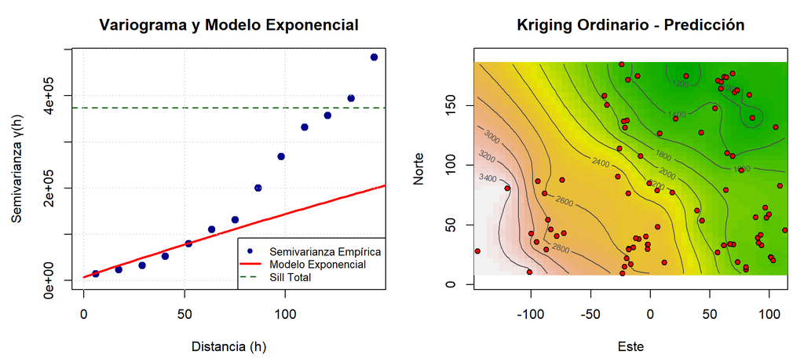

```r
# --- GRÁFICO DERECHA: Mapa de Kriging Ordinario ---
image(
  kc_ok,
  loc = grid_pred,
  col = terrain.colors(50),
  main = "Kriging Ordinario - Predicción",
  xlab = "Este",
  ylab = "Norte"
)
contour(kc_ok, loc = grid_pred, add = TRUE, col = "gray30") # Corregido de kc_uk a kc_ok
points(aquiferg$coords, pch = 21, bg = "red", col = "black", cex = 0.9)
```

```r
# Restaurar panel gráfico
par(mfrow = c(1, 1))
```

**Mapa 2: Regresión con Dependencia Espacial (Máxima Verosimilitud)**

Se modela la tendencia en función de las coordenadas $(x, y)$ y se estiman los parámetros por Máxima Verosimilitud (Kriging Universal).

```r
# ==============================================================================
# 3. MAPA 2: REGRESIÓN ESPACIAL / KRIGING UNIVERSAL (MÁXIMA VEROSIMILITUD)
# ==============================================================================

# a) Ajuste del modelo de verosimilitud con tendencia lineal (~coords)
fit_ml <- likfit(
  aquiferg,
  ini.cov.pars = ini_pars,
  cov.model    = "exponential",
  trend        = ~coords
)

# b) Variograma empírico de los RESIDUALES (removiendo la tendencia lineal)
v_emp_res <- variog(aquiferg, trend = ~coords, max.dist = 150)

# c) Predicción por Kriging Universal (UK) en la grilla
kc_uk <- krige.conv(
  aquiferg,
  locations = grid_pred,
  krige = krige.control(
    type.krige = "ok",       # En geoR la presencia de trend activa el Kriging Universal
    trend.d    = ~coords,    # Tendencia en los datos
    trend.l    = ~coords,    # Tendencia en la grilla
    cov.model  = fit_ml$cov.model,
    cov.pars   = fit_ml$cov.pars,
    nugget     = fit_ml$nugget
  )
)
```

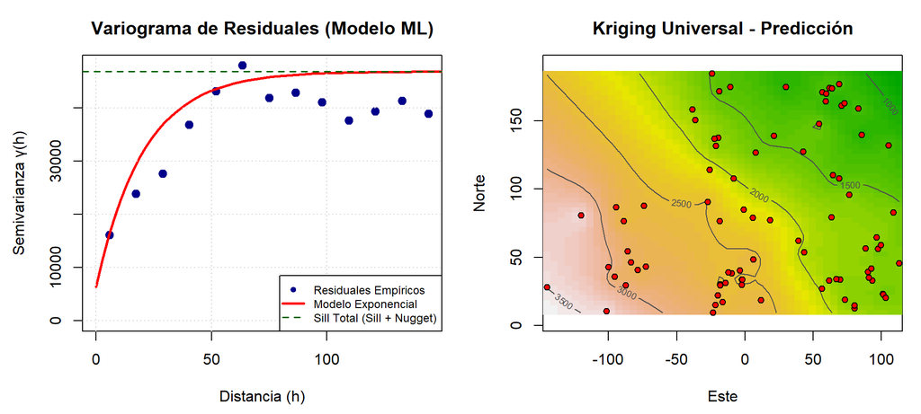

```r
# ------------------------------------------------------------------------------
# VISUALIZACIÓN PANEL DOBLE (IZQUIERDA: VARIOGRAMA | DERECHA: MAPA)
# ------------------------------------------------------------------------------
par(mfrow = c(1, 2), mar = c(4.5, 4.5, 3, 1))

# --- GRÁFICO IZQUIERDA: Variograma de Residuales + Ajuste ML ---
plot(
  v_emp_res,
  main = "Variograma de Residuales (Modelo ML)",
  xlab = "Distancia (h)",
  ylab = "Semivarianza γ(h)",
  pch = 19,
  col = "darkblue",
  cex = 1.2
)

# Superponer la curva del modelo ajustado por ML
lines(fit_ml, col = "red", lty = 1, lwd = 2.5)

# Línea de la varianza muestral de referencia
abline(h = fit_ml$nugget + fit_ml$cov.pars[1], col = "darkgreen", lty = 2, lwd = 1.5)
grid(col = "gray85", lty = 3)

# Leyenda explicativa
legend(
  "bottomright",
  legend = c("Residuales Empíricos", "Modelo Exponencial", "Sill Total (Sill + Nugget)"),
  col = c("darkblue", "red", "darkgreen"),
  pch = c(19, NA, NA),
  lty = c(NA, 1, 2),
  lwd = c(NA, 2.5, 1.5),
  bty = "o",
  bg = "white",
  cex = 0.75
)

# --- GRÁFICO DERECHA: Mapa 2 - Predicción por Kriging Universal ---
image(
  kc_uk,
  loc = grid_pred,
  col = terrain.colors(50),
  main = "Kriging Universal - Predicción",
  xlab = "Este",
  ylab = "Norte"
)
contour(kc_uk, loc = grid_pred, add = TRUE, col = "gray30")
points(aquiferg$coords, pch = 21, bg = "red", col = "black", cex = 0.9)
```

```r
# Restaurar la configuración gráfica por defecto
par(mfrow = c(1, 1))
```

**Regresión por Mínimos Cuadrados Ordinarios (OLS) vs. Máxima Verosimilitud (ML)**

Comparamos un modelo de regresión lineal (que ignora la autocorrelación espacial) con el modelo ajustado por `likfit` (que la incluye).

```r
# --- A. Extracción de Métricas ---
mod_ols <- lm(Profundidad ~ Este + Norte, data = aquifer)

loglik_ols <- as.numeric(logLik(mod_ols))
aic_ols    <- AIC(mod_ols)
bic_ols    <- BIC(mod_ols)
k_ols      <- length(coef(mod_ols)) + 1

loglik_ml  <- fit_ml$loglik
aic_ml     <- fit_ml$AIC
bic_ml     <- fit_ml$BIC
k_ml       <- fit_ml$npars

# --- B. Construcción de la Tabla Estilizada ---
tabla_comp <- data.frame(
  Modelo     = c("OLS (Mínimos Cuadrados)", "ML (Espacial Exponencial)"),
  Parámetros = c(k_ols, k_ml),
  `Log-Lik`  = round(c(loglik_ols, loglik_ml), 2),
  AIC        = round(c(aic_ols, aic_ml), 2),
  BIC        = round(c(bic_ols, bic_ml), 2),
  `Δ AIC`    = round(c(aic_ols - min(aic_ols, aic_ml), aic_ml - min(aic_ols, aic_ml)), 2)
)

kable(tabla_comp, caption = "Comparación de Criterios de Información (OLS vs. ML Espacial)", align = "lcccccc") %>%
  kable_styling(bootstrap_options = c("striped", "hover", "condensed", "responsive"), full_width = FALSE) %>%
  row_spec(2, bold = TRUE, background = "#E8F4F8") # Resalta el mejor modelo (ML)
```

| Modelo | Parámetros | Log.Lik | AIC | BIC | Δ.AIC |
| --- | --- | --- | --- | --- | --- |
| OLS (Mínimos Cuadrados) | 4 | -570.82 | 1149.63 | 1159.41 | 18.11 |
| ML (Espacial Exponencial) | 6 | -559.76 | 1131.52 | 1146.18 | 0.00 |

```r
# --- C. Test de Razón de Verosimilitud (LRT) ---
lrt_stat <- 2 * (loglik_ml - loglik_ols)
p_value  <- pchisq(lrt_stat, df = k_ml - k_ols, lower.tail = FALSE)
```

**Resultado del Test de Razón de Verosimilitud (LRT):**

- **Estadístico LR:** $22.113$
- **Grados de Libertad:** $6-4=2$
- **p-valor:** $<<0.001$

El modelo con estructura de covarianza espacial (ML) superó significativamente al modelo OLS ($\Delta\text{AIC} = 18.11, p < 0.001$), lo que confirma la presencia de dependencia espacial en los residuos.

**Comparación de la Regresión (ML) con el Kriging Ordinario**

Se usa Validación Cruzada Leave-One-Out (LOOCV), que calcula el Error Cuadrático Medio (RMSE) de las predicciones.

```r
# Se ocultan las salidas de consola redundantes de xvalid
cv_ok <- xvalid(aquiferg, model = fit_ok, trend = ~1)
cv_uk <- xvalid(aquiferg, model = fit_ml, trend = ~coords)
```

```r
# --- Métricas de Desempeño Predictivo ---
rmse_ok <- sqrt(mean(cv_ok$error^2))
rmse_uk <- sqrt(mean(cv_uk$error^2))
mae_ok  <- mean(abs(cv_ok$error))
mae_uk  <- mean(abs(cv_uk$error))

tabla_cv <- data.frame(
  Método = c("Kriging Ordinario", "Kriging Universal"),
  Tendencia = c("Constante (~1)", "Lineal (~Este + Norte)"),
  RMSE = round(c(rmse_ok, rmse_uk), 3),
  MAE  = round(c(mae_ok, mae_uk), 3)
)

kable(tabla_cv, caption = "Métricas de Error de Validación Cruzada (LOOCV)", align = "llcc") %>%
  kable_styling(bootstrap_options = c("striped", "hover", "condensed"), full_width = FALSE) %>%
  column_spec(3, bold = TRUE, color = "#2B5C8F")
```

Table 1: Table 2: Métricas de Error de Validación Cruzada (LOOCV)

| Método | Tendencia | RMSE | MAE |
| --- | --- | --- | --- |
| Kriging Ordinario | Constante (~1) | 177.881 | 136.904 |
| Kriging Universal | Lineal (~Este + Norte) | 176.846 | 139.231 |

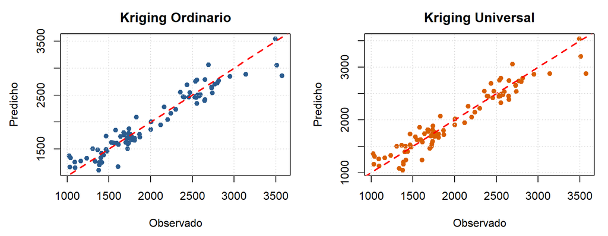

Figure 1: Validez de ajuste predicho vs. observado para Kriging Ordinario y Universal.

```r
par(mfrow = c(1, 2), mar = c(4.5, 4.5, 2.5, 1))

# Panel 1: Kriging Ordinario
plot(
  cv_ok$data, cv_ok$predicted,
  main = "Kriging Ordinario",
  xlab = "Observado", ylab = "Predicho",
  pch = 19, col = "#2B5C8F", cex = 0.9
)
abline(0, 1, col = "red", lty = 2, lwd = 2)
grid(col = "gray85", lty = 3)

# Panel 2: Kriging Universal
plot(
  cv_uk$data, cv_uk$predicted,
  main = "Kriging Universal",
  xlab = "Observado", ylab = "Predicho",
  pch = 19, col = "#D95F02", cex = 0.9
)
abline(0, 1, col = "red", lty = 2, lwd = 2)
grid(col = "gray85", lty = 3)
```

```r
par(mfrow = c(1, 1))
```

### 1.7 Simule campos aleatorios espaciales bajo el supuesto de normalidad multivariada, para varios tipos de autocovarianza espacial.

Grafique los dispersogramas rezagados variando modelos y parámetros. Esto es, en cada caso, grafique $Y(s)$ Vs $Y(s+h)$, para varios valores de $h$. y en cada caso calcule el coeficiente de correlación de Pearson. Analice.

**R/**

Si un campo aleatorio espacial $Y(s)$ es gaussiano, se tiene que cualquier conjunto finito de ubicaciones $\{s_1, s_2, \dots, s_n\}$ sigue una distribución normal multivariada. Esto garantiza que la dependencia espacial este definida por la media $\mu$ y la matriz de covarianza $\Sigma$.

> **Nota sobre Estacionariedad:**  
> Para un proceso gaussiano, la estacionariedad débil (o de segundo orden) implica automáticamente estacionariedad fuerte (estricta).

Se plantean los siguientes modelos para la función de covarianza $C(h)$:

- **Exponencial:** $C(h) = \sigma^2 \exp(-h/a)$.
- **Gaussiano:** $C(h) = \sigma^2 \exp(-(h/a)^2)$.
- **Esférico:** $C(h) = \sigma^2 [1 - \frac{3}{2}(h/a) + \frac{1}{2}(h/a)^3]$ si $h \le a$, y $0$ si $h > a$.

La correlación teórica es $\rho(h) = \frac{C(h)}{C(0)} = \frac{C(h)}{\sigma^2}$. A medida que la distancia $h$ se incrementa respecto al rango $a$, $\rho(h) \to 0$, por lo que la elipse del dispersograma rezagado se abre progresivamente hasta convertirse en un círculo (independencia lineal).

```r
# ==============================================================================
# FUNCIONES VECTORIZADAS DE SIMULACIÓN
# ==============================================================================

# Construcción eficiente de la matriz de covarianza usando outer()
build_cov_matrix <- function(s, model, sigma2 = 1, range_a = 15) {
  H <- abs(outer(s, s, "-")) # Matriz de distancias h_ij

  Sigma <- switch(model,
    "exponential" = sigma2 * exp(-H / range_a),
    "gaussian"    = sigma2 * exp(-(H / range_a)^2),
    "spherical"   = ifelse(H <= range_a,
                           sigma2 * (1 - 1.5 * (H / range_a) + 0.5 * (H / range_a)^3),
                           0)
  )
  return(Sigma)
}

# Generador de gráficos de dispersión de pares rezagados Y(s) vs Y(s+h)
plot_lagged_scatter <- function(Y, Sigma, model, range_a, lag_k, delta_s = 1) {
  N <- length(Y)
  h_val <- lag_k * delta_s

  df <- data.frame(
    Y_s  = Y[1:(N - lag_k)],
    Y_sh = Y[(lag_k + 1):N]
  )

  r_empirico <- cor(df$Y_s, df$Y_sh)
  r_teorico  <- Sigma[1, 1 + lag_k]

  p <- ggplot(df, aes(x = Y_s, y = Y_sh)) +
    geom_point(alpha = 0.45, color = "#2B5C8F", size = 1.2) +
    geom_abline(slope = 1, intercept = 0, color = "#D95F02", linetype = "dashed", linewidth = 0.8) +
    labs(
      title = paste0(toupper(model), " (a = ", range_a, ", h = ", h_val, ")"),
      subtitle = sprintf("r = %.3f | ρ(h) = %.3f", r_empirico, r_teorico),
      x = expression(Y(s)),
      y = expression(Y(s+h))
    ) +
    coord_fixed(ratio = 1) +
    theme_minimal(base_size = 10) +
    theme(
      plot.title = element_text(face = "bold", size = 10),
      plot.subtitle = element_text(color = "#800000", face = "bold", size = 9),
      panel.grid.minor = element_blank()
    )

  return(list(plot = p, r_emp = r_empirico, r_teo = r_teorico, model = model, range = range_a, lag = h_val))
}
```

```r
# Configuración del experimento
set.seed(2026) # Reproducibilidad
N <- 300
s <- 1:N
mu <- rep(0, N)

# --- Experimento 1: Efecto del Rango y Rezago (Modelo Exponencial) ---
S_exp15 <- build_cov_matrix(s, "exponential", range_a = 15)
Y_exp15 <- mvrnorm(n = 1, mu = mu, Sigma = S_exp15)

S_exp30 <- build_cov_matrix(s, "exponential", range_a = 30)
Y_exp30 <- mvrnorm(n = 1, mu = mu, Sigma = S_exp30)

S_exp60 <- build_cov_matrix(s, "exponential", range_a = 60)
Y_exp60 <- mvrnorm(n = 1, mu = mu, Sigma = S_exp60)

e1 <- plot_lagged_scatter(Y_exp15, S_exp15, "exponential", range_a = 15, lag_k = 5)
e2 <- plot_lagged_scatter(Y_exp15, S_exp15, "exponential", range_a = 15, lag_k = 10)
e3 <- plot_lagged_scatter(Y_exp15, S_exp15, "exponential", range_a = 15, lag_k = 40)
e4 <- plot_lagged_scatter(Y_exp30, S_exp30, "exponential", range_a = 30, lag_k = 5)
e5 <- plot_lagged_scatter(Y_exp30, S_exp30, "exponential", range_a = 30, lag_k = 10)
e6 <- plot_lagged_scatter(Y_exp30, S_exp30, "exponential", range_a = 30, lag_k = 40)
e7 <- plot_lagged_scatter(Y_exp60, S_exp60, "exponential", range_a = 60, lag_k = 5)
e8 <- plot_lagged_scatter(Y_exp60, S_exp60, "exponential", range_a = 60, lag_k = 10)
e9 <- plot_lagged_scatter(Y_exp60, S_exp60, "exponential", range_a = 60, lag_k = 40)

# --- Experimento 2: Comparación de Estructuras (Rango a=30, Rezago h=20) ---
S_exp10 <- build_cov_matrix(s, "exponential", range_a = 10)
S_gau10 <- build_cov_matrix(s, "gaussian",    range_a = 10)
S_sph10 <- build_cov_matrix(s, "spherical",   range_a = 10)

Y_exp10 <- mvrnorm(n = 1, mu = mu, Sigma = S_exp10)
Y_gau10 <- mvrnorm(n = 1, mu = mu, Sigma = S_gau10)
Y_sph10 <- mvrnorm(n = 1, mu = mu, Sigma = S_sph10)

S_exp30 <- build_cov_matrix(s, "exponential", range_a = 30)
S_gau30 <- build_cov_matrix(s, "gaussian",    range_a = 30)
S_sph30 <- build_cov_matrix(s, "spherical",   range_a = 30)

Y_exp30 <- mvrnorm(n = 1, mu = mu, Sigma = S_exp30)
Y_gau30 <- mvrnorm(n = 1, mu = mu, Sigma = S_gau30)
Y_sph30 <- mvrnorm(n = 1, mu = mu, Sigma = S_sph30)

m_exp1 <- plot_lagged_scatter(Y_exp10, S_exp10, "exponential", range_a = 10, lag_k = 2)
m_gau1 <- plot_lagged_scatter(Y_gau10, S_gau10, "gaussian",    range_a = 10, lag_k = 2)
m_sph1 <- plot_lagged_scatter(Y_sph10, S_sph10, "spherical",   range_a = 10, lag_k = 2)

m_exp2 <- plot_lagged_scatter(Y_exp30, S_exp30, "exponential", range_a = 30, lag_k = 20)
m_gau2 <- plot_lagged_scatter(Y_gau30, S_gau30, "gaussian",    range_a = 30, lag_k = 20)
m_sph2 <- plot_lagged_scatter(Y_sph30, S_sph30, "spherical",   range_a = 30, lag_k = 20)
```

**Relación entre Rango ($a$) y Rezago ($h$)**

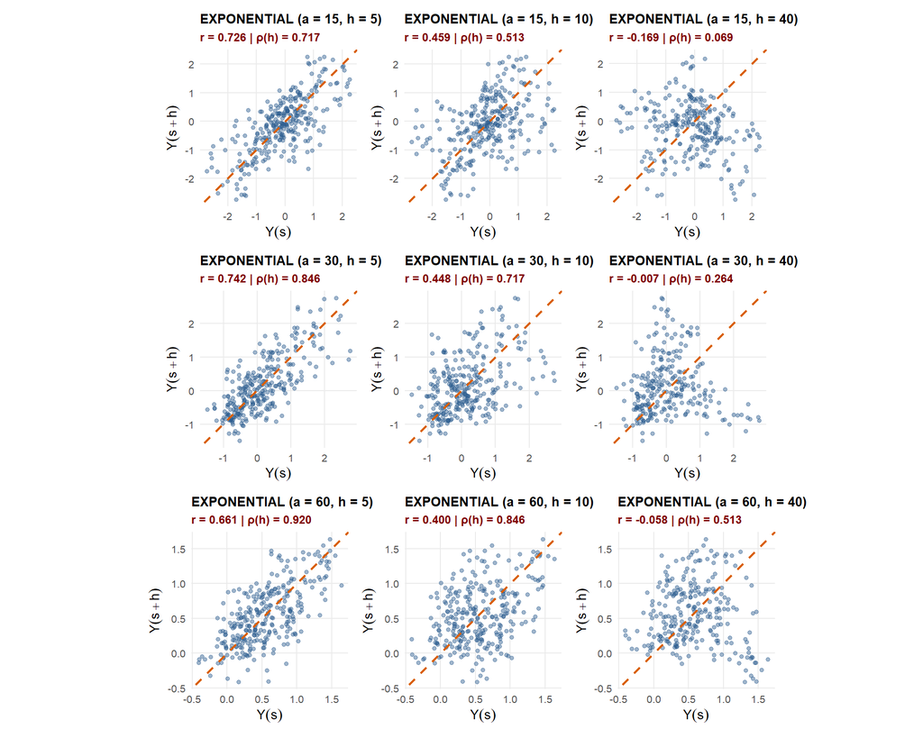

Figure 2: Evaluación del modelo exponencial variando la distancia h y el rango práctico a.

```r
(e1$plot | e2$plot| e3$plot) / (e4$plot | e5$plot| e6$plot) / (e7$plot | e8$plot| e9$plot)
```

**Comparación entre Modelos de Autocovarianza**

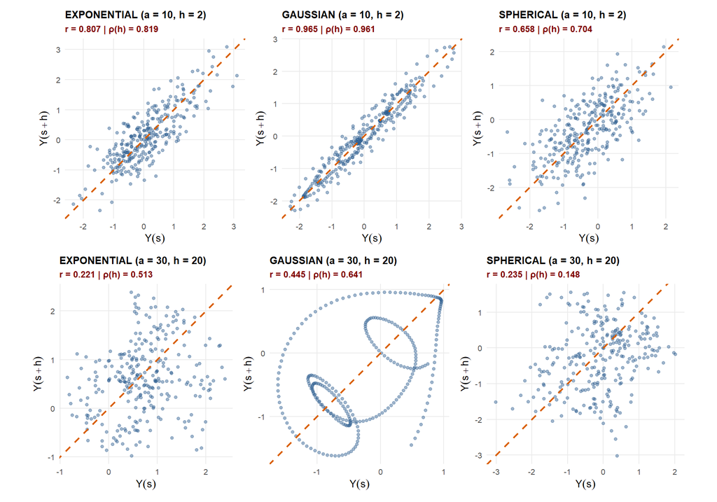

```r
(m_exp1$plot | m_gau1$plot | m_sph1$plot) / (m_exp2$plot | m_gau2$plot | m_sph2$plot)
```

El comportamiento geométrico de las realizaciones refleja claramente el tipo de continuidad espacial que implementa cada modelo cerca del origen. El *modelo Gaussiano* evidencia la mayor suavidad espacial pues en el origen tiene $C'(0)=0$, registrando las mayores correlaciones tanto a escalas cortas ($a=10, h=2; r = 0.965, \rho = 0.961$) como intermedias ($a=30, h=20; r = 0.445, \rho = 0.641$) mediante trayectorias armónicas y muy ordenadas.

En contraste, el *modelo Exponencial* presenta una caída lineal inicial que genera campos más irregulares ($r = 0.807$ y $r = 0.221$), mientras que el *modelo Esférico* impone un límite de correlación estricto en $h \ge a$, mostrando un decaimiento más acelerado a distancias intermedias ($r = 0.235, \rho = 0.148$) que dispersa rápidamente la nube de puntos.

Esto se ve mejor en la siguiente tabla resumen, donde se comparan las correlaciones teóricas y empíricas para cada modelo y combinación de parámetros.

Table 3: Table 4: Comparación de correlaciones teóricas y empíricas.

| Modelo | Rango (a) | Rezago (h) | r (Muestral) | ρ(h) (Teórico) | Error Absoluto |
| --- | --- | --- | --- | --- | --- |
| exponential | 15 | 5 | 0.726 | 0.717 | 0.009 |
| exponential | 15 | 10 | 0.459 | 0.513 | 0.054 |
| exponential | 15 | 40 | -0.169 | 0.069 | 0.238 |
| exponential | 30 | 5 | 0.742 | 0.846 | 0.104 |
| exponential | 30 | 10 | 0.448 | 0.717 | 0.269 |
| exponential | 30 | 40 | -0.007 | 0.264 | 0.271 |
| exponential | 60 | 5 | 0.661 | 0.920 | 0.259 |
| exponential | 60 | 10 | 0.400 | 0.846 | 0.446 |
| exponential | 60 | 40 | -0.058 | 0.513 | 0.571 |
| exponential | 10 | 2 | 0.807 | 0.819 | 0.012 |
| gaussian | 10 | 2 | 0.965 | 0.961 | 0.004 |
| spherical | 10 | 2 | 0.658 | 0.704 | 0.046 |
| exponential | 30 | 20 | 0.221 | 0.513 | 0.292 |
| gaussian | 30 | 20 | 0.445 | 0.641 | 0.196 |
| spherical | 30 | 20 | 0.235 | 0.148 | 0.087 |

### 1.8 Se requiere llevar a cabo predicción espacial para un proceso espacial cuya distribución marginal es lognormal con media conocida. ¿Es posible encontrar un predictor insesgado? Demuestre o refute.

**R/**

Es posible, pero como **el predictor de kriging aplicado directamente sobre la escala lognormal no es insesgado**, hay que aplicar una corrección por sesgo.

En ejercicios anteriores se demostró que

$$W^*(s_0) = \Psi(Y^*(s_0)) + \frac{1}{2} \Psi''(\mu) \sigma_K^2.$$

En este caso,

$$\Psi(y) = e^y,$$

por lo que

$$\Psi''(y) = e^y.$$

Evaluando en la media,

$$\Psi''(\mu) = e^\mu.$$

Entonces,

$$W^*(s_0) = e^{Y^*(s_0)} + \frac{1}{2}e^{\mu}\sigma_K^2.$$

Esta es una aproximación de segundo orden obtenida mediante Taylor.

Como

$$Y(s_0) \mid \text{datos} \sim N\left(Y^*(s_0), \sigma_K^2\right),$$

se utiliza la propiedad de la distribución lognormal:

$$X \sim N(m, v),
\longrightarrow
E(e^X) = e^{m + \frac{v}{2}}.$$

Por lo tanto,

$$E[Z(s_0) \mid \text{datos}] = E[e^{Y(s_0)} \mid \text{datos}] = e^{Y^*(s_0) + \frac{1}{2}\sigma_K^2}.$$

Así, el predictor insesgado es

$$Z^*(s_0) = \exp \left( Y^*(s_0) + \frac{1}{2} \sigma_K^2 \right),$$

donde

$$\sigma_K^2 = \text{Var}[Y(s_0) - Y^*(s_0)].$$

Por lo tanto el estimador insesgado es:

$$Z^*(s_0) = \exp \left( Y^*(s_0) + \frac{1}{2} \operatorname{Var}[Y(s_0) - Y^*(s_0)] \right),$$

### 1.9 Generalice el resultado encontrado en el problema anterior, al caso en el que se transforma la variable usando una transformación Box-Cox.

**R/**

Del resultado obtenido en **9.4.2**

$$W^*(s_0) = \Psi(Y^*(s_0)) + \frac{1}{2} \Psi''(\mu_y) \text{Var}[Y(s_0) - Y^*(s_0)].$$

Para

$$\Psi(y) = \frac{y^\lambda - 1}{\lambda}, \quad \lambda \neq 0,$$

se tiene

$$\Psi'(y) = y^{\lambda - 1},$$

y

$$\Psi''(y) = (\lambda - 1)y^{\lambda - 2}.$$

Sustituyendo en la expresión anterior,

$$W^*(s_0) = \frac{(Y^*(s_0))^\lambda - 1}{\lambda} + \frac{1}{2}(\lambda - 1)\mu_y^{\lambda - 2} \text{Var}[Y(s_0) - Y^*(s_0)].$$

Cuando

$$\lambda = 0,$$

la transformación Box-Cox coincide con la transformación logarítmica,

$$\Psi(y) = \ln(y).$$

En este caso,

$$\Psi''(y) = -\frac{1}{y^2},$$

por lo que

$$W^*(s_0) = \ln(Y^*(s_0)) - \frac{\text{Var}[Y(s_0) - Y^*(s_0)]}{2\mu_y^2}.$$